# PYTHON FOR DATA ANALYSIS - Scrapping Session

## Objectifs :

Maitrise requests + beautifoulsoup et / ou selenium Maitrise Outils de developpement web / HTML CSS / clic droit inspecter / CSS selectors

Choisissez un thème de scraping parmi les suivants :

- Resultats sportifs : date, équipe/joueur 1 , équipe/joueur2, score ..
- Stock market : date/heure, stock, valeur
- Google search results pour un mot clé donné : titre page, description, url, position
- Pollution : date/heure mesure, indice mesuré, valeur
- playlist radio : date/heure diffusion, artiste, morceau (https://www.nova.fr/radionova/radio-nova )
- site marchand : marque, nom produit , prix ...
- **annonces immo : titre, prix , m2**

Automatisez la collecte des données en vous limitant à 100 résultats dans un premier temps Insérez les données propres dans un DataFrame, en ne conservant que les données utiles. Choisissez un affichage révélateur, graphique ou sous forme de tableau.

Aspect légal : c'est l'utilisation que vous allez en faire qui peut être condamnée, par le scraping en soi.

## Import des libraires

```python
import time  # deal with time and random to make more human-like typing

# deal with data
import json
import numpy as np
import pandas as pd
import matplotlib.pyplot as plt
from matplotlib.ticker import PercentFormatter
plt.rcParams['figure.figsize'] = [12, 5]
plt.rcParams['figure.dpi'] = 200
plt.rcParams['font.size'] = 7.5 # default = 10.0


# regular expressions
import re

# deal with HTML structures
from bs4 import BeautifulSoup

# deal with fully controlled webdriver from python notebook
import selenium
from selenium import webdriver
from selenium.webdriver.common.keys import Keys
from selenium.webdriver.support import ui
from selenium.webdriver.common.action_chains import ActionChains
```

## Variables d'extraction

### Sélection

Pour le travail de web scrapping j'ai décidé d'extraire les données des pages web de logic immo. Plus particulièrement, ce site répertorie des annonces de biens à vendre/louer avec plusieurs filtres possibles dont :

- La(les) location(s)
- La surface minimum si précisé
- Le prix minimum si précisé
- Le prix maximum si précisé
- ... (D'autres filtres avancés sont présents mais je ne les traiterais pas)

[figure not shown]

Je propose alors de renseigner ces champs qui seront ainsi automatiquement remplis par selenium. Aussi, dans un soucis du détail, un dernier champ proposé, on peut choisir le nombre de données à extraire. (Plus loin le descriptif des données à extraire)

```python
# Do not touch the STARTING_URL
STARTING_URL = "https://www.logic-immo.com/"

# Select search places filter (List of string or None)
SEARCH_PLACES = ['ARCUEIL', 'l\'hay les roses', 'cachan']

# Select miminmum surface (in m² or None)
MIN_SURFACE = None

# Select miminmum and maximum price (in € or None))
MIN_PRICE = None
MAX_PRICE = 2_000_000


# Maximum data to extract (None to scrap every items)
MAX_DATA = 100
```

### Sanity checks

Faisons tout de même un rapide check que les variables renseignées soient intelligemment définies.

- Le nombre de places possible pour filtrer les bien est de 3 (défini par logic immo)
- Les prix et surfaces sont évidemment des entiers naturels
- Le minimum est inférieur au maximum

```python
# SANITY CHECK : SEARCH_PLACES
if SEARCH_PLACES is not None:
    SEARCH_PLACES = [SEARCH_PLACES] if isinstance(SEARCH_PLACES, str) else SEARCH_PLACES
    # on vérifie que le nombre de place est au maximum 3
    assert len(SEARCH_PLACES) < 4, "SEARCH_PLACES is limited to 3 search places"
    # on vérifie que tous les elements soient des string
    for place in SEARCH_PLACES:
        assert isinstance(place, str), "SEARCH_PLACES must be a list of string if not None"

# SANITY CHECK : MIN_PRICE and MAX_PRICE
if MIN_PRICE is not None:
    assert isinstance(MIN_PRICE, int), "MIN_PRICE must be None or a positive integer"

if MAX_PRICE is not None:
    if MIN_PRICE is None:
        assert MAX_PRICE >= 0 and isinstance(MAX_PRICE, int), "MAX_PRICE must be None or a positive integer"
    else:
        assert MAX_PRICE >= MIN_PRICE and isinstance(MAX_PRICE, int), "MAX_PRICE must be None or a positive integer >= MIN_PRICE"

    print('Everything is checked')
```

```
Everything is checked
```

## Simulation de Navigation et Extraction des données

Avant de commencer le webscrapping je vais définir quelques fonctions que je réutiliserai afin de rendre la navigation et la lecture du code plus intelligible.

### Simplification d'écriture pour trouver les éléments web

Lors du webscrapping, j'aurai à rechercher des elements dans les pages web par leur selecteur css ou encore par xpath. Quoiqu'il en soit, je me fais une petite fonction pour qu'en une ligne on puisse traiter tous les cas. Cela me permets aussi de gérer les erreurs et de retourner un None lorsqu'il y a une erreur où quand ma recherche n'a pas abouti

```python
def find_element(driver, by, pattern, debug=False):
    element = None
    if by == 'css_selector':
        try: element = driver.find_element_by_css_selector(pattern)
        except: pass
    elif by == 'xpath':
        try: element = driver.find_element_by_xpath(pattern)
        except: pass

    if element is None and debug:
        print(f'The element was not found by {by} "{pattern}" in the driver {driver}.')
    return element
```

Aussi, pour que le webscrapping soit visuellement plus agréable et plus ressemblant à la navigatio humaine sur internet, je me fais une petite fonction sleep qui permet d'attendre un certain temps avec de l'aléatoire. Cela simulera entre autres, l'écriture des variables dans les champs de filtre pour la recherche.

```python
def sleep(t=0.15, minimum=0.05, std_ratio=1):
    time.sleep(max(minimum, np.random.normal(t, t * std_ratio)))
```

### Ouverture du driver

```python
driver = webdriver.Firefox()
```

### Navigation vers Logic-Immo et sélection des filtres

#### Accès à Logic Immo

On se redirige tout d'emblée à la page d'accueil du site logic immo.

```python
driver.get(STARTING_URL)
```

#### Filtre des lieux d'achat

Comme précisé tout à l'heure, on rentre les champs de recherche comme un humain le ferait. De gauche à droite en rentrant les champs caractère par caractère avant validation.

[figure not shown]

Les filtre sur les lieux est particulier car il est possible qu'il ne soit pas reconnu par logic immo. Alors dans ce cas, tant pis, on abandonne ce fitlre et on passe au prochain lieu s'il existe.

```python
if SEARCH_PLACES is not None:
    # get the input of the places
    place_input = find_element(driver, 'css_selector', '#s2id_autogen1')

    # write each place (human-like) then press enter to vaselect2-result-labellidate them
    for place in SEARCH_PLACES:
        place_input.clear()
        for char in place:
            sleep() # time before typing character
            place_input.send_keys(char)


        sleep(0.5, 0.2) # time before check and validate the place


        # sanity check : place found
        first_place_result = find_element(driver, 'css_selector', '.select2-result-sub > li > div')

        if first_place_result is None:
            print(f'Err : The place "{place}" was not found...')
        else:
            # press enter to select the place
            inner_html = first_place_result.get_attribute("innerHTML")
            extracted_place = re.sub(r'<span.*>(.*)</span>(.*)', r'\g<1>\g<2>', inner_html)
            print(f'{extracted_place} found...')
            place_input.send_keys(Keys.ENTER)
```

```
ARCUEIL (94110) found...
L'HAY LES ROSES (94240) found...
CACHAN (94230) found...
```

#### Filtre sur la surface minimale

Le cas des la surface et du prix est plus simple, et le sanity check a déjà été effectué alors on entre juste les données dans les bonnes cases et hop !

```python
if MIN_SURFACE is not None:
    # get the input of min surface
    min_surface_input = find_element(driver, 'css_selector', '#areaMinDesk')
    min_surface_input.clear()
    for char in str(MIN_SURFACE):
        sleep() # time before typing character
        min_surface_input.send_keys(char)

        sleep(0.5, 0.2) # little time ;)
```

#### Filtre sur le prix minimal et maximal

```python
if MIN_PRICE is not None:
    # get the input of min price
    min_price_input = find_element(driver, 'css_selector', '#priceMinDesk')
    min_price_input.clear()
    for char in str(MIN_PRICE):
        sleep() # time before typing character
        min_price_input.send_keys(char)

        sleep(0.5, 0.2) # little time ;)


if MAX_PRICE is not None:
    # get the input of max price
    max_price_input = find_element(driver, 'css_selector', '#priceMaxDesk')
    max_price_input.clear()
    for char in str(MAX_PRICE):
        sleep() # time before typing character
        max_price_input.send_keys(char)

        sleep(0.5, 0.2) # little time ;)
```

#### Lancement de la recherche

Y'a plus qu'à... On appuie sur le bouton de recherche pour lancer la sélection.

```python
submit_button = find_element(driver, 'css_selector', '#js-submitBtnHO')
ActionChains(driver).move_to_element(submit_button).click(submit_button).perform()
```

### Récupération des données

Avant de commencer quoique ce soit, analysons un petit peu cette page

[figure not shown]

- On peut alors voir que la page est composée de plusieurs items qui sont tous sur une même colonne. Cela va grandement nous simplifier la tache.
- En analysant un peu plus on se rend compte que les items sont composés d'item qui sont les annonces et d'items qui sont en plus des container, qui coresspondent aux publicités ou autres blocs.

#### Trouver les items

J'aimerai avoir une logique d'itération "tant qu'il y a des items", les extraires et rester sur la même page. Alors je me fais une petite fonction pour trouver tous les items et préciser si ce sont des container (pubs) ou non.

```python
def find_item(idx):
    is_container = False
    # easy find item
    item = find_element(driver, 'css_selector', f".offer > .offer-list-item:nth-child({page_item_idx})")
    # or the item can be as ".offer-list-item-CONTAINER"
    if item is None:
        item = find_element(driver, 'css_selector', f".offer > .offer-list-item-container:nth-child({page_item_idx})")
        is_container = True
    return item, is_container
```

#### Extraires les informations des items

Enfin, pour les items qui sont bien des annonces il faudra bien évidemment les extraires. Alors analysons de quoi ils sont composés.

[figure not shown]

On peut alors constater que les items peuvent être constituer des données suivantes :

- flag d'exclusivité **[bool]**
- nombre de photo **[int]**
- un ou plusieurs types de bien dont on précisera la liste **[bool]s**
- surface du bien **[int]**
- nombre de pièce **[int]**
- nombre de chambre **[int]**
- lieu et code postal **[str]** et **[str]**
- prix d'achat **[int]**
- publicité pour prix de location mensuel avec partenaire **[int]**

Si un champ n'est pas trouvable, on considéreras que celui-ci n'est pas existant, il ne sera alors pas précisé dans le dataframe final (**NaN**) sauf pour le nombre de photo qu'on considéras être **1** par défaut

```python
types = ['vente', 'appartement', 'maison', 'terrain', 'villa', 'viager', 'propriété']

def extract_data(item):
    data = {}
    soup = BeautifulSoup(item.get_attribute('innerHTML'))

    data["flag"] = soup.find('div', {"class": 'flag-container'})
    data["flag"] = data["flag"] is not None and data["flag"].get_text() != ''

    # find and extract the number of picture if exists else 1
    try:
        n_pict_text = soup.find('span', {"class": 'offer-picture-count'}).get_text()
        n_pict_text = n_pict_text.replace('\n', ' ')
        data["n_picture"] = int(re.sub(r'.*\d+/(\d+).*', r'\g<1>', n_pict_text))
    except: data["n_picture"] = 1

    # extract the data types separated by a space in the items
    data_types = soup.find('span', {"class": 'offer-details-type'})
    data_types = data_types.get_text().lower().split(' ') if data_types is not None else []
    for t in types:
        data[f'is_{t}'] = (t in data_types) * 1

    # extract the area and the number of room/bedroom
    data['area'] = soup.find('span', {"class": 'offer-area-number'})
    data['area'] = int(data['area'].get_text()) if data['area'] is not None else None
    data['n_room'] = soup.select('.offer-details-caracteristik--rooms > span')
    data['n_room'] = int(data['n_room'][0].get_text()) if len(data['n_room']) else None
    data['n_bedroom'] = soup.select('.offer-details-caracteristik--bedrooms > span')
    data['n_bedroom'] = int(data['n_bedroom'][0].get_text()) if len(data['n_bedroom']) else None

    # extract localition and zip code
    data['location'] = soup.find('span', {"class": 'offer-details-location--locality'})
    data['location'] = data['location'].get_text() if data['location'] is not None else None
    if data['location'] is not None:
        # sous format "{Location_name} ({Zip_code})"
        data['zipcode'] = re.sub(r'(.*) \((\d+)\)', r'\g<2>', data['location'])
        data['location'] = re.sub(r'(.*) \((\d+)\)', r'\g<1>', data['location'])

    # then extract price and month rent
    data['price'] = soup.find('p', {"class": 'offer-price'})
    data['price'] = data['price'].get_text() if data['price'] is not None else None
    if data['price'] is not None:
        data['price'] = data['price'].replace('\n', '').replace(' ', '')
        data['price'] = int(re.sub(r'(\d+)€', r'\g<1>', data['price']))

    data['month_rent'] = soup.find('p', {"class": 'offer-bank'})
    data['month_rent'] = data['month_rent'].get_text() if data['month_rent'] is not None else None
    if data['month_rent'] is not None:
        data['month_rent'] = data['month_rent'].replace('\n', '').replace(' ', '')
        data['month_rent'] = int(re.sub(r'Ou(\d+)€/mois.*', r'\g<1>', data['month_rent']))

    # cleaning
    data = {k: v for k, v in data.items() if v is not None}
    return data
```

#### Web Scrapping

On peut alors lancer la machine !

Tant que nous n'avons pas tout extrait ou que la limite de donnée n'est pas atteinte :

- On récupère l'item suivant
- Si cet item est une annonce (pas un container) :
  - On extrait les données
  - On ajoute ces données un DataFrame
- Si on est arrivé à la fin de la page (l'item N n'existe pas), alors on passe à la page suivante (si existante)

A noter deux élements qui sont importants. Le premier étant qu'une flèche (bouttton) existe pour passer à la page suivante. Ceci réduit considérablement la difficulté. On appui toujours sur ce bouton jusqu'à ce qu'il n'apparaisse plus. (Logic Immog : Je t'aime)

[figure not shown]

Deuxièmement, au bout de la troisième page, une alerte s'affiche pour nous demander de s'inscrire à une alerte automatique suivant notre recherche. **Cet element bloque toute possiblité d'action supplémentaire**. Il faut alors aller le chercher et le rendre invisible. (Logic Immog : Je t'aime pas)

[figure not shown]

```python
page_item_idx = 1     # index of the items in the current page
count = 0             # number of items extracted

data = pd.DataFrame()   # to store items data when extracted

while MAX_DATA is None or count < MAX_DATA:

    # get the page_item_idx'th item
    item, is_container = find_item(page_item_idx)

    # check if it is the end of the webpage
    if item is not None:

        # skip the item if container (ads) or empty example div (.extendBoostMeaLow)
        if is_container or item.get_attribute('id') == 'extendBoostMeaLow':
            page_item_idx += 1
            continue

        # add the new item data
        data = data.append(extract_data(item), ignore_index=True)
        page_item_idx += 1
        count += 1

    else:
        # get the next-button to go the next webpage
        next_button = find_element(driver, 'css_selector', '.next')
        # check if there is a next webpage else stop the scrapping
        if next_button is not None:


            page_item_idx = 1
            sleep(3, 2, 0.1)  # sleep around 3s before clicking on the button
            try: next_button.click()
            except:   # F*** this popup alert blocking all the webpage hidding it
                popup = find_element(driver, 'xpath', "//div[@id='colorbox']")
                driver.execute_script("arguments[0].style.visibility='hidden'", popup)
                find_element(driver, 'css_selector', '#cboxOverlay').click()

        else:
            break
print(f'There is no more item to reach\n{count} item(s) on {MAX_DATA} extracted.')
```

```
There is no more item to reach
100 item(s) on 100 extracted.
```

#### Sauvegarde des données scrappées en format CSV

```python
data.to_csv('logic_immo_scrapped_data.csv', index=False)
data
```

|  | area | flag | is_appartement | is_maison | is_propriété | is_terrain | is_vente | is_viager | is_villa | month_rent | n_bedroom | n_picture | n_room | price | location | zipcode |
| --- | --- | --- | --- | --- | --- | --- | --- | --- | --- | --- | --- | --- | --- | --- | --- | --- |
| 0 | 165.0 | 1.0 | 0.0 | 1.0 | 0.0 | 0.0 | 1.0 | 0.0 | 0.0 | 3933.0 | 5.0 | 6.0 | 7.0 | 987000.0 | NaN | NaN |
| 1 | 97.0 | 1.0 | 1.0 | 0.0 | 0.0 | 0.0 | 1.0 | 0.0 | 0.0 | 1450.0 | 2.0 | 1.0 | 4.0 | 364000.0 | L Hay Les Roses | 94240 |
| 2 | 83.0 | 1.0 | 0.0 | 1.0 | 0.0 | 0.0 | 1.0 | 0.0 | 0.0 | 1865.0 | 2.0 | 4.0 | 3.0 | 468000.0 | L Hay Les Roses | 94240 |
| 3 | 95.0 | 1.0 | 0.0 | 1.0 | 0.0 | 0.0 | 1.0 | 0.0 | 0.0 | 2610.0 | 3.0 | 9.0 | 5.0 | 655000.0 | L Hay Les Roses | 94240 |
| 4 | 325.0 | 0.0 | 0.0 | 0.0 | 0.0 | 0.0 | 1.0 | 0.0 | 1.0 | 3128.0 | 4.0 | 10.0 | 10.0 | 785000.0 | Arcueil | 94110 |
| ... | ... | ... | ... | ... | ... | ... | ... | ... | ... | ... | ... | ... | ... | ... | ... | ... |
| 95 | 60.0 | 0.0 | 1.0 | 0.0 | 0.0 | 0.0 | 1.0 | 0.0 | 0.0 | 1362.0 | 2.0 | 3.0 | 3.0 | 342000.0 | Cachan | 94230 |
| 96 | 61.0 | 1.0 | 1.0 | 0.0 | 0.0 | 0.0 | 1.0 | 0.0 | 0.0 | 1366.0 | NaN | 6.0 | 3.0 | 343000.0 | Cachan | 94230 |
| 97 | 99.0 | 0.0 | 1.0 | 0.0 | 0.0 | 0.0 | 1.0 | 0.0 | 0.0 | 1370.0 | 5.0 | 7.0 | 6.0 | 344000.0 | L Hay Les Roses | 94240 |
| 98 | 100.0 | 1.0 | 1.0 | 0.0 | 0.0 | 0.0 | 1.0 | 0.0 | 0.0 | 1370.0 | 5.0 | 6.0 | 6.0 | 344000.0 | L Hay Les Roses | 94240 |
| 99 | 61.0 | 1.0 | 1.0 | 0.0 | 0.0 | 0.0 | 1.0 | 0.0 | 0.0 | 1374.0 | NaN | 6.0 | 3.0 | 345000.0 | Cachan | 94230 |

100 rows × 16 columns

## Analyse préparation des données récoltées

Le fichier **logic_immo_scrapped_data_val_de_marne.csv** est le scrapping complet des annonces répertoriées sur [Logic-Immo](https://www.logic-immo.com/).

- **Date de scrapping :** 28/11/2020
- **Filtre lieux :** Val-De-Marne (94)
- **Filtre surface minimum :** Aucun
- **Filtre prix minimum :** Aucun
- **Filtre prix maximum :** 2 millions €

```python
df = pd.read_csv("logic_immo_scrapped_data_val_de_marne.csv")
df.describe().apply(lambda row: [f"{x:f}" for x in row])
```

|  | area | flag | is_appartement | is_maison | is_propriété | is_terrain | is_vente | is_viager | is_villa | month_rent | n_bedroom | n_picture | n_room | price | zipcode |
| --- | --- | --- | --- | --- | --- | --- | --- | --- | --- | --- | --- | --- | --- | --- | --- |
| count | 6336.000000 | 6379.000000 | 6379.000000 | 6379.000000 | 6379.000000 | 6379.000000 | 6379.000000 | 6379.000000 | 6379.000000 | 6370.000000 | 5575.000000 | 6379.000000 | 6359.000000 | 6379.000000 | 6191.000000 |
| mean | 83.685290 | 0.484872 | 0.745415 | 0.225584 | 0.000941 | 0.000000 | 0.995454 | 0.004546 | 0.007838 | 1678.381162 | 2.589596 | 6.451795 | 3.729989 | 422232.659508 | 94317.192699 |
| std | 48.388236 | 0.499810 | 0.435662 | 0.417999 | 0.030657 | 0.000000 | 0.067277 | 0.067277 | 0.088193 | 1014.335940 | 1.190728 | 2.785302 | 1.649415 | 255839.624733 | 200.180294 |
| min | 9.000000 | 0.000000 | 0.000000 | 0.000000 | 0.000000 | 0.000000 | 0.000000 | 0.000000 | 0.000000 | 96.000000 | 1.000000 | 1.000000 | 1.000000 | 24175.000000 | 94000.000000 |
| 25% | 56.000000 | 0.000000 | 0.000000 | 0.000000 | 0.000000 | 0.000000 | 1.000000 | 0.000000 | 0.000000 | 1038.500000 | 2.000000 | 4.000000 | 3.000000 | 261505.500000 | 94140.000000 |
| 50% | 72.000000 | 0.000000 | 1.000000 | 0.000000 | 0.000000 | 0.000000 | 1.000000 | 0.000000 | 0.000000 | 1430.000000 | 2.000000 | 6.000000 | 3.000000 | 359000.000000 | 94320.000000 |
| 75% | 96.000000 | 1.000000 | 1.000000 | 0.000000 | 0.000000 | 0.000000 | 1.000000 | 0.000000 | 0.000000 | 1916.000000 | 3.000000 | 9.000000 | 5.000000 | 483000.000000 | 94455.000000 |
| max | 715.000000 | 1.000000 | 1.000000 | 1.000000 | 1.000000 | 0.000000 | 1.000000 | 1.000000 | 1.000000 | 7970.000000 | 16.000000 | 10.000000 | 19.000000 | 1999999.000000 | 94880.000000 |

### Données manquantes

#### Global

Avant de commencer tout traitement de donnée sur nos données manquantes, vérifions d'abord globalement quelles sont les données manquantes et quel est leur proportion par colonne.

|  | index | mean |
| --- | --- | --- |
| 10 | n_bedroom | 0.126039 |
| 14 | location | 0.029472 |
| 15 | zipcode | 0.029472 |
| 0 | area | 0.006741 |
| 12 | n_room | 0.003135 |
| 9 | month_rent | 0.001411 |

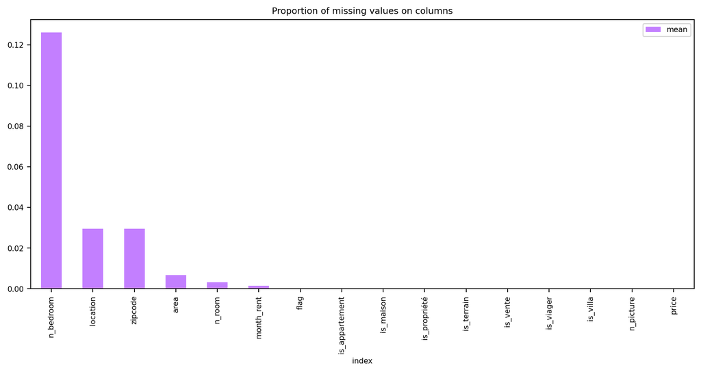

```python
missing_values = df.isnull().mean(axis=0).reset_index(name='mean').sort_values(by='mean', ascending=False)
missing_values.plot(x='index', title='Proportion of missing values on columns', kind='bar', color='#8800ff', alpha=0.5)
missing_values[missing_values["mean"] > 0]
```

#### Area

On va enlever les lignes où la surface est manquante. C'est la donnée de base qu'on donnera comme élément indispensable et preuve de la qualité de la donnée extraite.

```
Suppression de 43 lignes où "area" est manquant.
Valeurs manquantes après suppression :
```

|  | index | mean |
| --- | --- | --- |
| 10 | n_bedroom | 0.125316 |
| 14 | location | 0.029514 |
| 15 | zipcode | 0.029514 |
| 12 | n_room | 0.002999 |
| 9 | month_rent | 0.001420 |

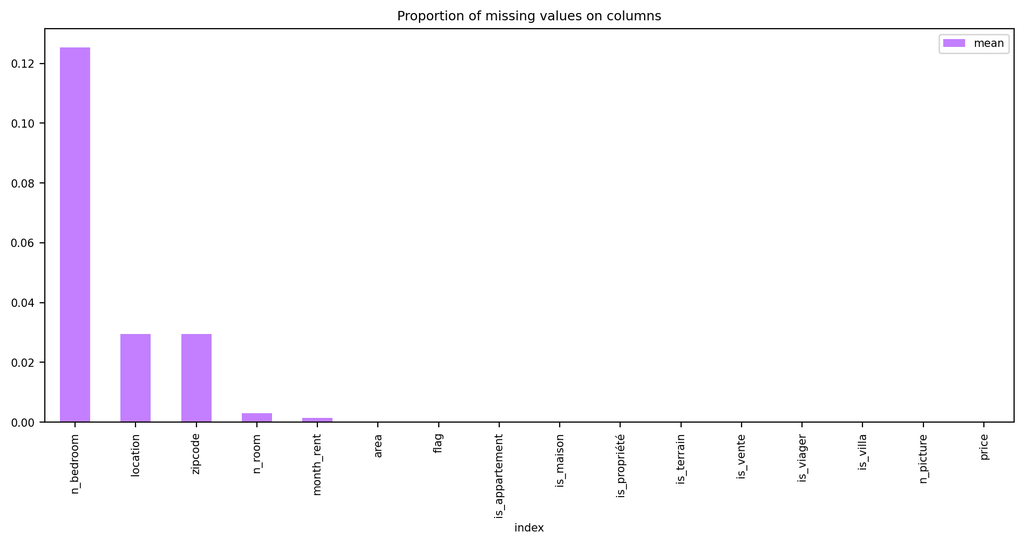

```python
print(f'Suppression de {df.area.isna().sum()} lignes où "area" est manquant.')
df = df.dropna(subset=['area'])
print('Valeurs manquantes après suppression :')
missing_values = df.isnull().mean(axis=0).reset_index(name='mean').sort_values(by='mean', ascending=False)
missing_values.plot(x='index', title='Proportion of missing values on columns', kind='bar', color='#8800ff', alpha=0.5)
missing_values[missing_values["mean"] > 0]
```

On peut alors s'occuper des valeurs manquantes les plus présentes. Il s'agit du nombre de chambre n_bedroom. Dans la même logique on en profite pour traiter les données manquantes pour le nombre de pièce donné par n_room.

Assez logiquement, on peut penser qu'un regression entre "area" et ces deux champs peut donner un lien assez fort. Evidemment on ne fait pas de regression avec le prix de vente puisque ce sera notre target. On regarde alors la distribution des données manquantes par rapport à la taille des biens.

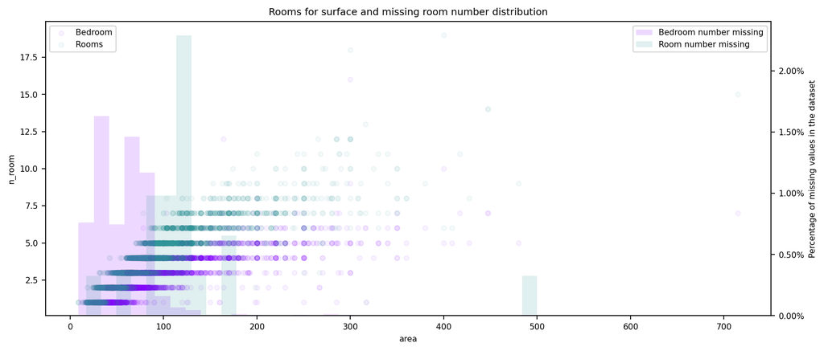

```python
fig, ax = plt.subplots()
df.plot(x='area', y='n_bedroom', kind='scatter', color='#8800ff', alpha=0.05, label='Bedroom', ax=ax)
df.plot(x='area', y='n_room', kind='scatter', color='#2f9599', alpha=0.05, label='Rooms', ax=ax)
plt.title('Rooms for surface and missing room number distribution')
ax.legend(loc='upper left')

ax = ax.twinx()  # instantiate a second axes that shares the same x-axis
ax.set_ylabel('Percentage of missing values in the dataset')

plt.hist(df[df.n_bedroom.isnull()].area, density=True, bins=30, color='#8800ff', alpha=0.15, label='Bedroom number missing')
plt.hist(df[df.n_room.isnull()].area, density=True, bins=30, color='#2f9599', alpha=0.15, label='Room number missing')
ax.legend(loc='upper right')
plt.gca().yaxis.set_major_formatter(PercentFormatter(1))

plt.show()
```

Suite à cela on peut faire quelques remarques évidentes :

- Le nombre de pièce et de chambre semble être proportionnel à la surface
- La distribution des données manquantes est très concentrée entre 0 et 200 m²

De part ces hypothèses on peut conclure que nous allons traiter les valeurs manquantes pour n_bedroom et n_room de la façon suivante :

- On fera une interpolation linéaire entre la surface et ces deux champs (sans arrondi, pas nécessaire)
- Il y a des outliers à la distribution des données manquantes qui peuvent fortement altérer l'interpolation.
- Avant de faire notre regression, validons l'hypothèse que les outliers (~5%) doivent être éliminés du calcul de la regression linéaire.

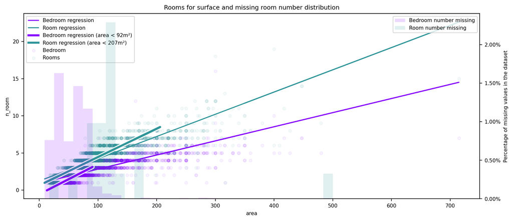

```python
fig, ax = plt.subplots()
df.plot(x='area', y='n_bedroom', kind='scatter', color='#8800ff', alpha=0.05, label='Bedroom', ax=ax)
df.plot(x='area', y='n_room', kind='scatter', color='#2f9599', alpha=0.05, label='Rooms', ax=ax)
plt.title('Rooms for surface and missing room number distribution')

# regression for rooms and bedrooms

x = np.array(df[df.n_bedroom.notna() & df.area.notna()].area.values)
y = np.array(df[df.n_bedroom.notna() & df.area.notna()].n_bedroom.values)
m_bedroom, b_bedroom = np.polyfit(x, y, 1)
ax.plot(x, m_bedroom * x + b_bedroom, color='#8800ff', label='Bedroom regression')
x = np.array(df[df.n_room.notna() & df.area.notna()].area.values)
y = np.array(df[df.n_room.notna() & df.area.notna()].n_room.values)
m_room, b_room = np.polyfit(x, y, 1)
ax.plot(x, m_room * x + b_room, color='#2f9599', label='Room regression')

# regression for rooms and bedrooms without outliers
limit_area = round(df[df.n_bedroom.isna()].area.quantile(0.95))
x = np.array(df[(df.area < limit_area) & (df.n_bedroom == df.n_bedroom)].area.values)
y = np.array(df[(df.area < limit_area) & (df.n_bedroom == df.n_bedroom)].n_bedroom.values)
m_bedroom, b_bedroom = np.polyfit(x, y, 1)
ax.plot(x, m_bedroom * x + b_bedroom, linewidth=6, color='#ffffff')
ax.plot(x, m_bedroom * x + b_bedroom, linewidth=3, color='#8800ff', label=f'Bedroom regression (area < {limit_area}m²)')

limit_area = round(df[df.n_room.isna()].area.quantile(0.95))
x = np.array(df[(df.area < limit_area) & (df.n_room == df.n_room)].area.values)
y = np.array(df[(df.area < limit_area) & (df.n_room == df.n_room)].n_room.values)
m_room, b_room = np.polyfit(x, y, 1)
ax.plot(x, m_room * x + b_room, linewidth=6, color='#ffffff')
ax.plot(x, m_room * x + b_room, linewidth=3, color='#2f9599', label=f'Room regression (area < {limit_area}m²)')

ax.legend(loc='upper left')
ax = ax.twinx()  # instantiate a second axes that shares the same x-axis
ax.set_ylabel('Percentage of missing values in the dataset')
plt.gca().yaxis.set_major_formatter(PercentFormatter(1))

plt.hist(df[df.n_bedroom.isnull()].area, density=True, bins=30, color='#8800ff', alpha=0.15, label='Bedroom number missing')
plt.hist(df[df.n_room.isnull()].area, density=True, bins=30, color='#2f9599', alpha=0.15, label='Room number missing')
ax.legend(loc='upper right')

plt.show()
```

#### n_room et n_bedroom

Que ce soit pour n_room et n_bedroom, on voit très clairement la différence entre la regression linéaire sur toutes les données est bien différente de celle effectuée sur l'intervalle des données manquantes avec une plus faible surface. Cela s'expliquement naïvement par le fait que plus un bien est grand, plus les pièces le sont, et donc, le nombre de pièce n'évolue pas de façon proportionnelle avec la surface mais légèrement logarithmiquement.

Donc notre regression sur l'intervalle de surface [0, quartile(0.95)] pour les données n_room et n_bedroom manquantes est bien plus pragmatique. Nous pouvons alors procéder à cette transformation.

[output not shown]

|  | index | mean |
| --- | --- | --- |
| 14 | location | 0.029514 |
| 15 | zipcode | 0.029514 |
| 9 | month_rent | 0.001420 |

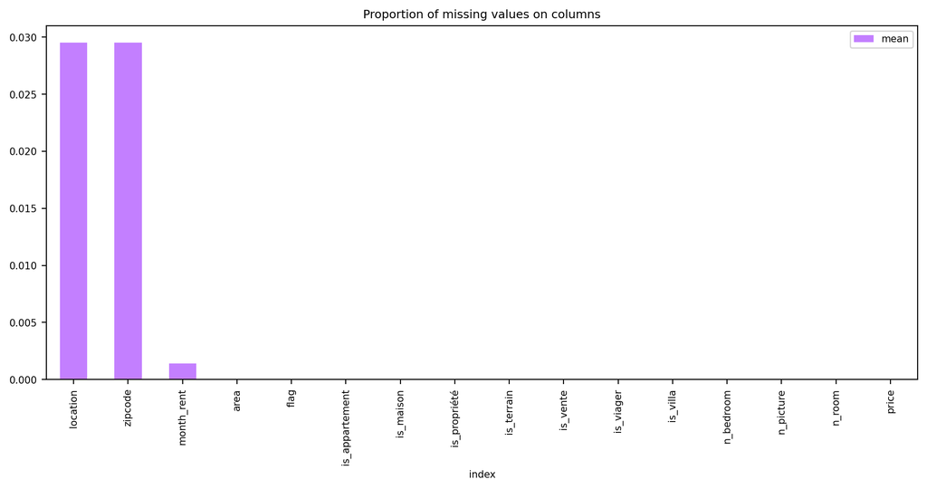

```python
# change the number of rooms according to what we obtained with 0.95 quantile
print(f'Interpolation de {df.n_room.isnull().sum()} lignes où "n_bedroom" est manquant.')
print(f'Interpolation de {df.n_bedroom.isnull().sum()} lignes où "n_room" est manquant.')
df.loc[df.n_bedroom.isnull(), "n_bedroom"] = m_bedroom * df["area"] + b_bedroom
df.loc[df.n_room.isnull(), "n_room"] = m_room * df["area"] + b_room

print('Valeurs manquantes après interpolation :')
missing_values = df.isnull().mean(axis=0).reset_index(name='mean').sort_values(by='mean', ascending=False)
missing_values.plot(x='index', title='Proportion of missing values on columns', kind='bar', color='#8800ff', alpha=0.5)
missing_values[missing_values["mean"] > 0]
```

#### location et zipcode

Pour la partie location (ville) et zipcode (code postal), il est assez facile de gérer les valeurs maquantes. Pour cela, il suffit d'ajouter une valeur signifiant ce manque.

```
Ajout de "__unkwown" pour 187 lignes où "location" est manquant.
Ajout de "__unkwown" pour 187 lignes où "zipcode" est manquant.
Valeurs manquantes après interpolation :
```

|  | index | mean |
| --- | --- | --- |
| 9 | month_rent | 0.00142 |

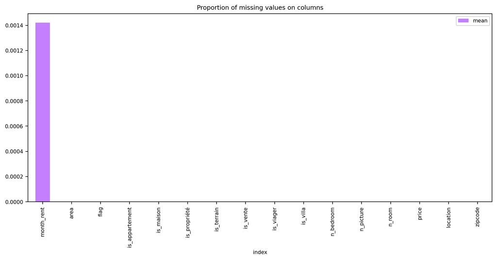

```python
# add "__unkwown" to the location and zipcode we don't jave
print(f'Ajout de "__unkwown" pour {df.location.isnull().sum()} lignes où "location" est manquant.')
print(f'Ajout de "__unkwown" pour {df.zipcode.isnull().sum()} lignes où "zipcode" est manquant.')
df.loc[df.location.isnull(), "location"] = "__unkwown"
df.loc[df.zipcode.isnull(), "zipcode"] = "__unkwown"

print('Valeurs manquantes après interpolation :')
missing_values = df.isnull().mean(axis=0).reset_index(name='mean').sort_values(by='mean', ascending=False)
missing_values.plot(x='index', title='Proportion of missing values on columns', kind='bar', color='#8800ff', alpha=0.5)
missing_values[missing_values["mean"] > 0]
```

#### month_rent

Il ne nous reste alors plus que le month_rent. Je pense que c'est quelque chose d'automatisé pour faire la publicité alors cela doit réfléter une simple règle plutôt qu'un prix réel.

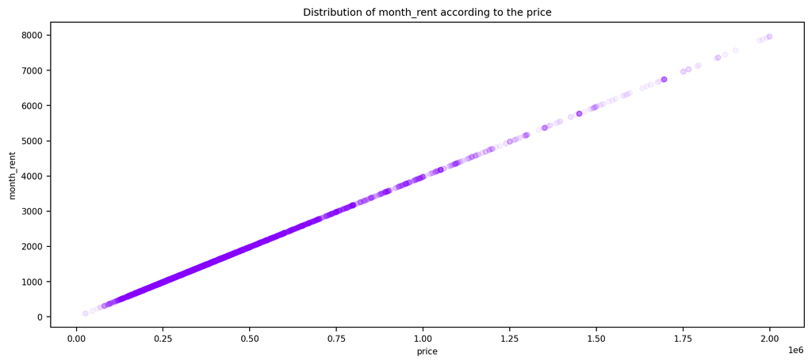

```python
df.plot(title='Distribution of month_rent according to the price', x='price', y='month_rent', kind='scatter', color='#8800ff', alpha=0.05)
pass
```

Les données me donnent raison. Et pour cela, ce serait de la triche que de garder cette donnée linéaire qui est totalement factice et basée sur le prix dans le but de prédire le prix.

```python
print(f'Pour information : le rapport de price par month_rent est de : {(df.price / df.month_rent).mean():.2f}')

print('Colonne month_rent supprimée !')
df = df.drop('month_rent', axis=1)
df
```

```
Pour information : le rapport de price par month_rent est de : 251.02
Colonne month_rent supprimée !
```

|  | area | flag | is_appartement | is_maison | is_propriété | is_terrain | is_vente | is_viager | is_villa | n_bedroom | n_picture | n_room | price | location | zipcode |
| --- | --- | --- | --- | --- | --- | --- | --- | --- | --- | --- | --- | --- | --- | --- | --- |
| 0 | 36.0 | 1.0 | 1.0 | 0.0 | 0.0 | 0.0 | 1.0 | 0.0 | 0.0 | 1.000000 | 5.0 | 2.0 | 210600.0 | __unkwown | __unkwown |
| 1 | 34.0 | 1.0 | 1.0 | 0.0 | 0.0 | 0.0 | 1.0 | 0.0 | 0.0 | 0.816647 | 6.0 | 1.0 | 139000.0 | Orly | 94310 |
| 2 | 24.0 | 1.0 | 1.0 | 0.0 | 0.0 | 0.0 | 1.0 | 0.0 | 0.0 | 0.411310 | 8.0 | 1.0 | 144000.0 | Vitry Sur Seine | 94400 |
| 3 | 17.0 | 1.0 | 1.0 | 0.0 | 0.0 | 0.0 | 1.0 | 0.0 | 0.0 | 0.127574 | 6.0 | 1.0 | 150000.0 | Maisons Alfort | 94700 |
| 4 | 37.0 | 1.0 | 1.0 | 0.0 | 0.0 | 0.0 | 1.0 | 0.0 | 0.0 | 1.000000 | 5.0 | 2.0 | 159900.0 | Limeil Brevannes | 94450 |
| ... | ... | ... | ... | ... | ... | ... | ... | ... | ... | ... | ... | ... | ... | ... | ... |
| 6374 | 205.0 | 1.0 | 1.0 | 0.0 | 0.0 | 0.0 | 1.0 | 0.0 | 0.0 | 4.000000 | 10.0 | 6.0 | 1979000.0 | __unkwown | __unkwown |
| 6375 | 163.0 | 0.0 | 0.0 | 1.0 | 0.0 | 0.0 | 1.0 | 0.0 | 0.0 | 3.000000 | 10.0 | 9.0 | 1990000.0 | Vincennes | 94300 |
| 6376 | 250.0 | 0.0 | 0.0 | 0.0 | 0.0 | 0.0 | 1.0 | 0.0 | 1.0 | 4.000000 | 10.0 | 7.0 | 1998000.0 | Le Perreux Sur Marne | 94170 |
| 6377 | 250.0 | 0.0 | 0.0 | 1.0 | 0.0 | 0.0 | 1.0 | 0.0 | 0.0 | 4.000000 | 10.0 | 6.0 | 1998000.0 | Le Perreux Sur Marne | 94170 |
| 6378 | 350.0 | 0.0 | 0.0 | 1.0 | 0.0 | 0.0 | 1.0 | 0.0 | 0.0 | 6.000000 | 9.0 | 7.0 | 1999999.0 | Chennevieres Sur Marne | 94430 |

6336 rows × 15 columns

### Distribution des données et preprocessing

```python
from custom_scaler import Scaler
scaler = Scaler()
```

#### Analyse de price

Commençons par examiner la distribution des prix étant donnée que c'est notre target. En l'occurence, les prix peuvent aller de 0 à +inf alors on peut déjà commencer par standardiser ces données.

```python
# creating a df to make some tests before
_df = df.copy()

# scaler.untransform(_df, 'price')
# _df['ground_truth'] = df['price']
# _df[['ground_truth', 'price']]
```

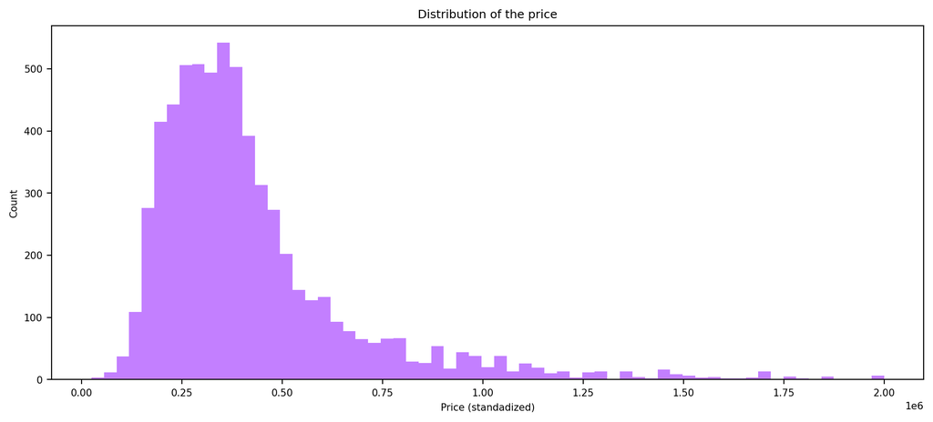

```python
N = len(_df) // 100

plt.hist(x=_df.price.values, bins=N, color='#8800ff', alpha=0.5)
plt.title('Distribution of the price')
plt.xlabel('Price (standadized)')
plt.ylabel('Count')
pass
```

On peut remarquer ques les données sont positive skewed. Alors nous alons garder notre standardisation en ajoutant en pretransformation un log recencter cette distribution.

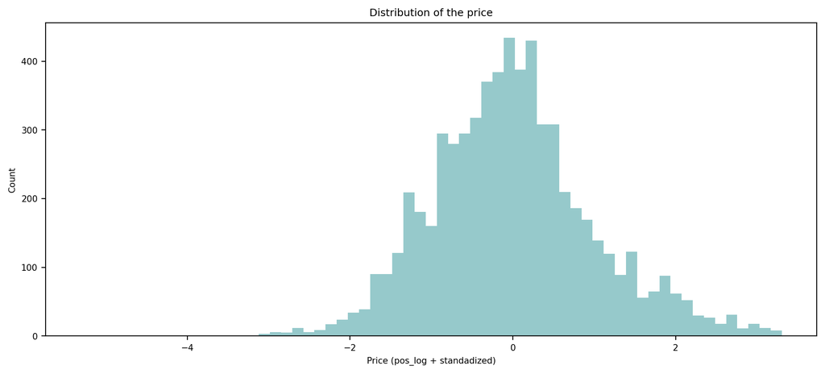

```python
_df['price'] = df['price']
scaler.fit_transform(_df, 'price', 'standardize', pre_t='pos_log')

plt.hist(x=_df.price.values, bins=N, color='#2f9599', alpha=0.5)
plt.title('Distribution of the price')
plt.xlabel('Price (pos_log + standadized)')
plt.ylabel('Count')
pass
```

#### Analyse de area

Passons maintenant à l'analyse de la surface des biens. Et plus encore, comparons avec cette distribution par rapport au prix des biens. A noter que le prix à déjà subit une transformation logarithmique. Si la surface évolue relativement linéairement avec le prix du bien alors ce sera sans surprise que l'on retrouvera une relation logarithmique entre la surface non tranformé et le prix transformé par un logarithme.

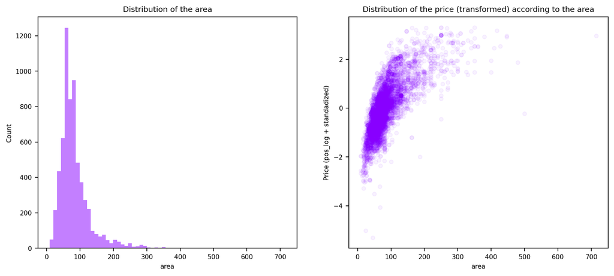

```python
_df['area'] = df['area']

fig, axes = plt.subplots(1, 2)
axes[0].hist(x=_df.area.values, bins=N, color='#8800ff', alpha=0.5)
axes[0].set_title('Distribution of the area')
axes[0].set_xlabel('area')
axes[0].set_ylabel('Count')

_df.plot(x='area', y='price', kind='scatter', color='#8800ff', alpha=0.05, ax=axes[1])
axes[1].set_title('Distribution of the price (transformed) according to the area')
axes[1].set_xlabel('area')
axes[1].set_ylabel('Price (pos_log + standadized)')
pass
```

En effet, on remarque très clairement la relation logarithmique entre la surface non tranformé et le prix transformé par un logarithme. Alors on peut se permettre d'effectuer cette même transformation sur la surface pour obtenir une relation linéaire entre area et price. D'ailleurs, on remarque que cette vairable area, elle aussi, a une distribution right skewed donc raison de plus pour effectuer la transformation logarithmique

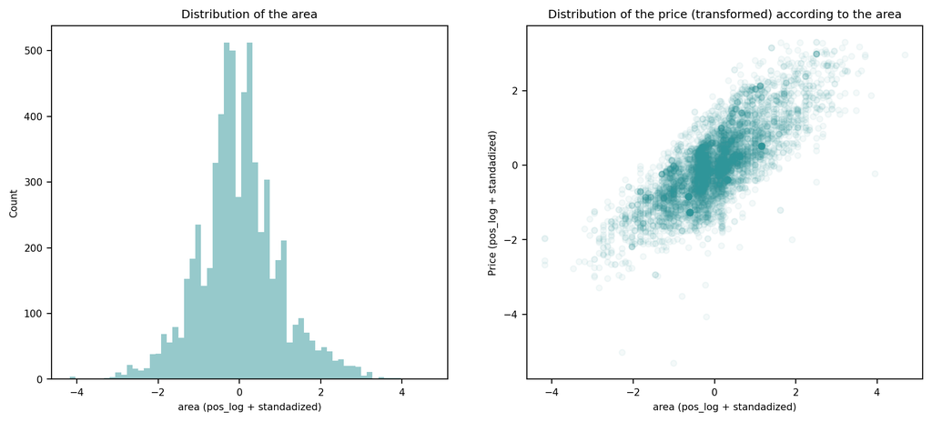

```python
_df['area'] = df['area']
scaler.fit_transform(_df, 'area', 'standardize', pre_t='pos_log')
fig, axes = plt.subplots(1, 2)
axes[0].hist(x=_df.area.values, bins=N, color='#2f9599', alpha=0.5)
axes[0].set_title('Distribution of the area')
axes[0].set_xlabel('area (pos_log + standadized)')
axes[0].set_ylabel('Count')

_df.plot(x='area', y='price', kind='scatter', color='#2f9599', alpha=0.05, ax=axes[1])
axes[1].set_title('Distribution of the price (transformed) according to the area')
axes[1].set_xlabel('area (pos_log + standadized)')
axes[1].set_ylabel('Price (pos_log + standadized)')
pass
```

#### Analyse de n_bedroom et n_room

Pour être franc, je n'ai pas d'apriori sur ces données, alors je vais effectuer les mêmes analyses que pour area. Mon seul apriori est que ces deux données sont très corrélées alors je vais les étudier ensemble.

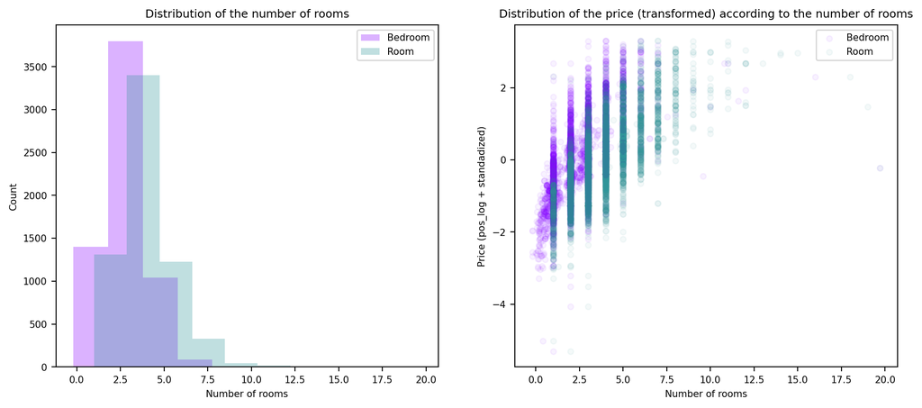

```python
_df['n_bedroom'] = df['n_bedroom']
_df['n_room'] = df['n_room']

fig, axes = plt.subplots(1, 2)
axes[0].hist(x=_df.n_bedroom.values, bins=10, color='#8800ff', alpha=0.3, label='Bedroom')
axes[0].hist(x=_df.n_room.values, bins=10, color='#2f9599', alpha=0.3, label='Room')
axes[0].set_title('Distribution of the number of rooms')
axes[0].set_xlabel('Number of rooms')
axes[0].set_ylabel('Count')
axes[0].legend()

_df.plot(x='n_bedroom', y='price', kind='scatter', color='#8800ff', alpha=0.05, label='Bedroom', ax=axes[1])
_df.plot(x='n_room', y='price', kind='scatter', color='#2f9599', alpha=0.05, label='Room', ax=axes[1])
axes[1].set_title('Distribution of the price (transformed) according to the number of rooms')
axes[1].set_xlabel('Number of rooms')
axes[1].set_ylabel('Price (pos_log + standadized)')
axes[0].legend()
pass
```

Finalement, on arrive aux même conclusions pour n_room et n_bedroom que pour area. Alors appliquons la même transformation.

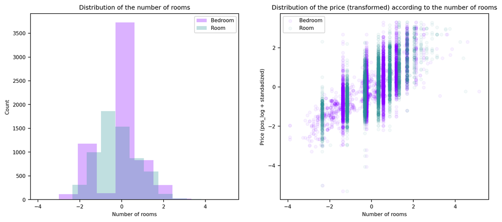

```python
_df['n_bedroom'] = df['n_bedroom']
_df['n_room'] = df['n_room']
scaler.fit_transform(_df, 'n_bedroom', 'standardize', pre_t='pos_log')
scaler.fit_transform(_df, 'n_room', 'standardize', pre_t='pos_log')

fig, axes = plt.subplots(1, 2)
axes[0].hist(x=_df.n_bedroom.values, bins=10, color='#8800ff', alpha=0.3, label='Bedroom')
axes[0].hist(x=_df.n_room.values, bins=10, color='#2f9599', alpha=0.3, label='Room')
axes[0].set_title('Distribution of the number of rooms')
axes[0].set_xlabel('Number of rooms')
axes[0].set_ylabel('Count')
axes[0].legend()

_df.plot(x='n_bedroom', y='price', kind='scatter', color='#8800ff', alpha=0.05, label='Bedroom', ax=axes[1])
_df.plot(x='n_room', y='price', kind='scatter', color='#2f9599', alpha=0.05, label='Room', ax=axes[1])
axes[1].set_title('Distribution of the price (transformed) according to the number of rooms')
axes[1].set_xlabel('Number of rooms')
axes[1].set_ylabel('Price (pos_log + standadized)')
axes[1].legend()
pass
```

#### Analyse de n_picture

Honnêtement, le nombre de photos des annonces est une donnée qui parait un peu bête. Je l'ai scrappée parce que je trouvais cela très drôle. Je ne pense pas pouvoir en tirer grand chose. Mais sait-on jamais, peut être qu'il y a des tendances comportementales qui poussent à prendre plus ou moins de photos à partir du prix.

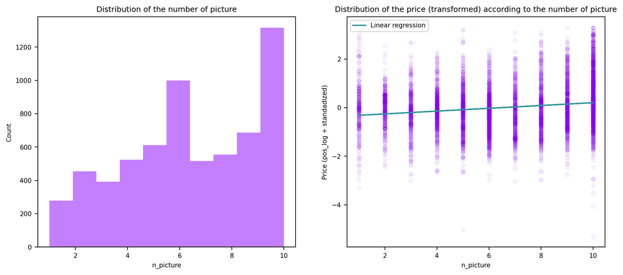

```python
_df['n_picture'] = df['n_picture']

fig, axes = plt.subplots(1, 2)
axes[0].hist(x=_df.n_picture.values, bins=10, color='#8800ff', alpha=0.5)
axes[0].set_title('Distribution of the number of picture')
axes[0].set_xlabel('n_picture')
axes[0].set_ylabel('Count')

_df.plot(x='n_picture', y='price', kind='scatter', color='#8800ff', alpha=0.05, ax=axes[1])
# add regression line
x = np.array(_df.n_picture.values)
y = np.array(_df.price.values)
m, b = np.polyfit(x, y, 1)
axes[1].plot(x, m * x + b, color='#2f9599', label='Linear regression')
axes[1].set_title('Distribution of the price (transformed) according to the number of picture')
axes[1].set_xlabel('n_picture')
axes[1].set_ylabel('Price (pos_log + standadized)')
axes[1].legend()
pass
```

Donc il semblerait qu'il n'y ait pas réellement de lie entre le prix et le nombre de photos mises sur le site internet. On remarque une petite petite petite augmentation en tracant une regression linéaire, mais cela ne saute pas aux yeux. Gardons tout de même cette variable

#### Variables qualitatives

On peut alors étudier un peu les variables qualitatives. On a :

- **flag :** qui précise si oui ou non il y avait un flag d'exclusivité sur l'annonce
- **is_appartement, is_maison, is_propriété, is_terrain, is_villa :** qui précise le type de bien à vendre
- **is_vente, is_viager :** qui précise le type de vente
- **location, zipcode :** qui précise le lieux (généralement la ville) donc ces deux informations sont redondantes

##### Analyse de Flag

| flag | price count | price mean | price min | price max | price median | price std |
| --- | --- | --- | --- | --- | --- | --- |
| 0.0 | 3264.00 | 0.14 | -5.31 | 3.31 | 0.07 | 1.02 |
| 1.0 | 3072.00 | -0.15 | -3.28 | 3.28 | -0.19 | 0.96 |

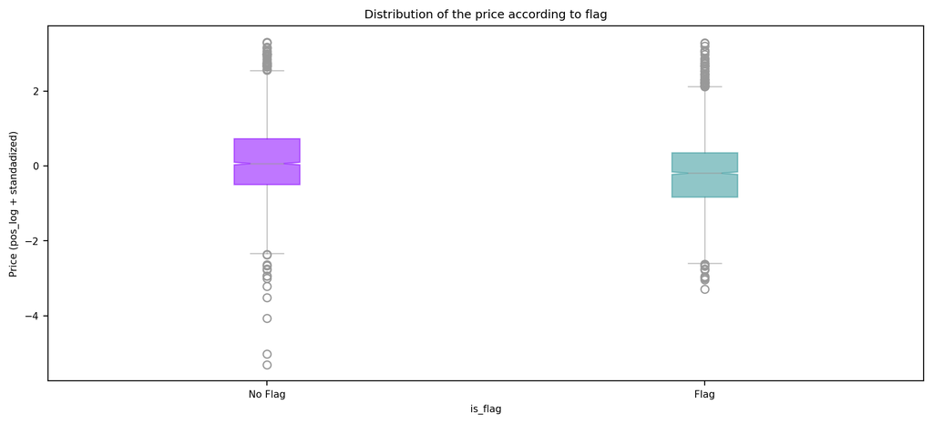

```python
# group by flag to get box plots
groups = _df.groupby(by='flag').price
groups = [groups.get_group(k) for k in groups.groups]
# custom colors
gray_dict = dict(color='#99999988', markeredgecolor='#999999')
colors = ['#8800ff88', '#2f959988']
boxplot = plt.boxplot(
    groups, notch=True, vert=True, patch_artist=True, labels=["No Flag", "Flag"],
    capprops=gray_dict, whiskerprops=gray_dict, flierprops=gray_dict, medianprops=gray_dict
)
# change box colors
for i, patch in enumerate(boxplot['boxes']):
    patch.set_color(colors[i%len(colors)])

plt.title('Distribution of the price according to flag')
plt.xlabel('is_flag')
plt.ylabel('Price (pos_log + standadized)')
# display multiple aggregates
_df.groupby('flag').agg({'price': ['count', 'mean', 'min', 'max', 'median', 'std']}).apply(lambda row: [f'{x:.2f}' for x in row])
```

On peut remarquer que la présence d'un flag ou non est bien répartie en deux groupes de même tailles. On ne voit pas vraiment à vu d'oeil d'implication du flag sur le prix. Une prix très légèrement supérieur quand il n'y a pas de flag mais l'écart type est plus important.

##### Analyse de vente et viager

On peut faire le même type d'analyse sur le type de vente. A savoir que le type de vente est soit un viager soit une vente normale. On peut donc faire une variables booléenne pour se simplifier le travail.

| is_vente | price count | price mean | price min | price max | price median | price std |
| --- | --- | --- | --- | --- | --- | --- |
| 0.0 | 28.00 | -1.62 | -5.31 | 1.92 | -1.55 | 1.55 |
| 1.0 | 6308.00 | 0.01 | -5.02 | 3.31 | -0.04 | 0.99 |

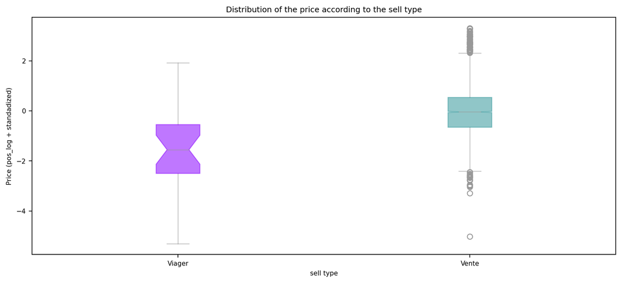

```python
# group by flag to get box plots
groups = _df.groupby(by='is_vente').price
groups = [groups.get_group(k) for k in groups.groups]
# custom colors
gray_dict = dict(color='#99999988', markeredgecolor='#999999')
colors = ['#8800ff88', '#2f959988']
boxplot = plt.boxplot(
    groups, notch=True, vert=True, patch_artist=True, labels=["Viager", "Vente"],
    capprops=gray_dict, whiskerprops=gray_dict, flierprops=gray_dict, medianprops=gray_dict
)
# change box colors
for i, patch in enumerate(boxplot['boxes']):
    patch.set_color(colors[i%len(colors)])

plt.title('Distribution of the price according to the sell type')
plt.xlabel('sell type')
plt.ylabel('Price (pos_log + standadized)')
# display multiple aggregates
_df.groupby('is_vente').agg({'price': ['count', 'mean', 'min', 'max', 'median', 'std']}).apply(lambda row: [f'{x:.2f}' for x in row])
```

On peut alors voir que les ventes en viager sont sous représentées par rapport aux ventes classiques. Aussi, bien que l'intervalle de confiance (~95%) de la mediane pour le viager soit important, on peut considérer que le prix de vente est inférieur dans ce type de vente. Il pourra alors être une bonne indication pour nos prédictions.

##### Analyse types de biens

Encore une fois dans la même logique, on peut essayer de visualiser si le type de bien a un impact sur le prix de vente. Pour cela on réutilise le code du dessus et on triche un peu en mettant tous les types de biens en une colonne (one hot encoding inverse).

| type_temp | price count | price mean | price min | price max | price median | price std |
| --- | --- | --- | --- | --- | --- | --- |
| Appartement | 4726.00 | -0.28 | -5.31 | 3.28 | -0.28 | 0.88 |
| Maison | 1431.00 | 0.84 | -2.20 | 3.31 | 0.71 | 0.87 |
| Propriété | 6.00 | 0.85 | -0.07 | 1.93 | 0.77 | 0.97 |
| Villa | 50.00 | 1.48 | -0.34 | 3.30 | 1.39 | 0.90 |
| __unknown | 123.00 | 0.37 | -1.75 | 2.81 | 0.14 | 0.74 |

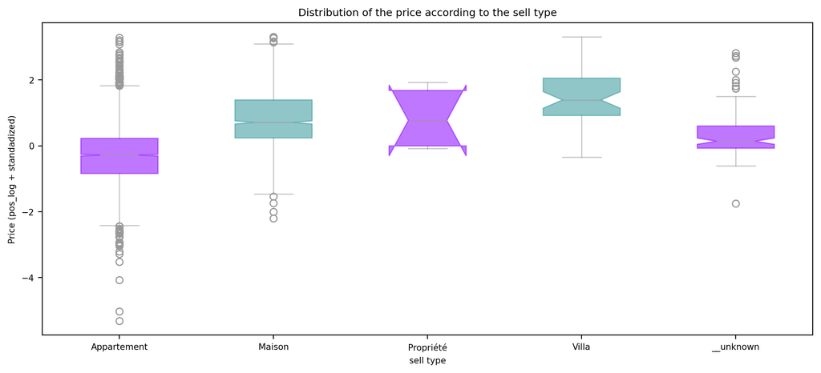

```python
# group by flag to get box plots
type_cols = ['is_appartement', 'is_maison', 'is_propriété', 'is_terrain', 'is_villa']

_df['type_temp'] = '__unknown'
for col in type_cols:
    name_type = col[3:]
    name_type = name_type[0].upper() + name_type[1:].lower()
    _df.loc[_df[col] == 1, 'type_temp'] = name_type

groups = _df.groupby(by='type_temp').price
labels = groups.count().reset_index(name='count').type_temp.values

groups = [groups.get_group(k) for k in groups.groups]

# custom colors
gray_dict = dict(color='#99999988', markeredgecolor='#999999')
colors = ['#8800ff88', '#2f959988']
boxplot = plt.boxplot(
    groups, notch=True, vert=True, patch_artist=True, labels=labels,
    capprops=gray_dict, whiskerprops=gray_dict, flierprops=gray_dict, medianprops=gray_dict
)
# change box colors
for i, patch in enumerate(boxplot['boxes']):
    patch.set_color(colors[i%len(colors)])

plt.title('Distribution of the price according to the sell type')
plt.xlabel('sell type')
plt.ylabel('Price (pos_log + standadized)')
# display multiple aggregates and remove the temporary columns
types_groups = _df.groupby('type_temp').agg({'price': ['count', 'mean', 'min', 'max', 'median', 'std']}).apply(lambda row: [f'{x:.2f}' for x in row])
del _df['type_temp']
types_groups
```

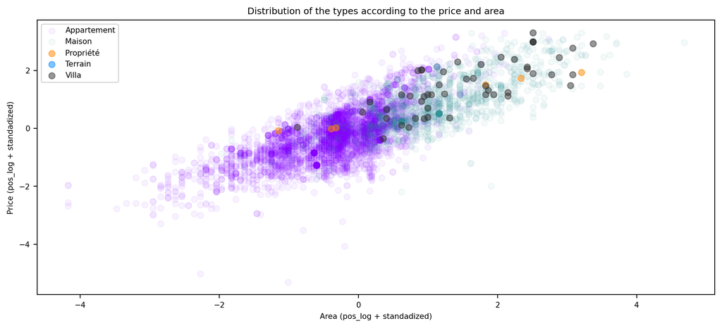

```python
# group by flag to get box plots
type_cols = ['is_appartement', 'is_maison', 'is_propriété', 'is_terrain', 'is_villa']
colors = ["#8800ff", '#2f9599', '#0088ff', '#ff8800', '#992f95']
colors = ["#8800ff", '#2f9599', '#ff8800', '#0088ff', '#333333']
alphas = [0.05, 0.05, 0.5, 0.5, 0.5]
fig, ax = plt.subplots()
for type_col, color, alpha in zip(type_cols, colors, alphas):
    name_type = type_col[3:]
    name_type = name_type[0].upper() + name_type[1:].lower()
    type_df = _df[_df[type_col] == 1]
    ax.scatter(type_df.area, type_df.price, color=color, alpha=alpha, label=name_type)

ax.legend()
plt.title('Distribution of the types according to the price and area')
plt.xlabel('Area (pos_log + standadized)')
plt.ylabel('Price (pos_log + standadized)')
pass
```

En effet, on remarque que c'est davantage la surface qui impact le prix avec un comportement liénaire, sans détachement visible en fonction des types de bien. On note aussi que les appartements sont majoritairement plus petits et inversement pour les maisons et villa qui semblent avoir la même distribution surface/prix.

##### Analyse locations

Enfin, on peut analyser la location (ville) et le zipcode que l'on a dans nos données. On peut se permettre de supprimer le zipcode car il est une information redondante de la location. Voyons alors la répartition des locations dans les villes.

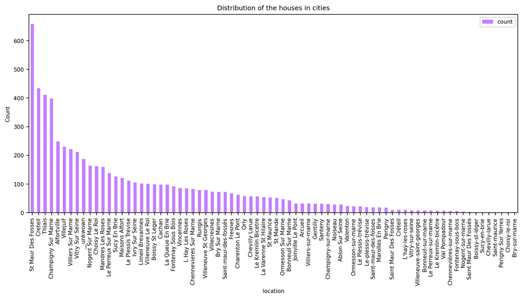

```python
sorted_locations = df.groupby(by='location')['location'].count().reset_index(name='count').sort_values(by='count', ascending=False)
sorted_locations.plot(x='location', kind='bar', color='#8800ff', alpha=0.5)
plt.title('Distribution of the houses in cities')
plt.xlabel('location')
plt.ylabel('Count')
pass
```

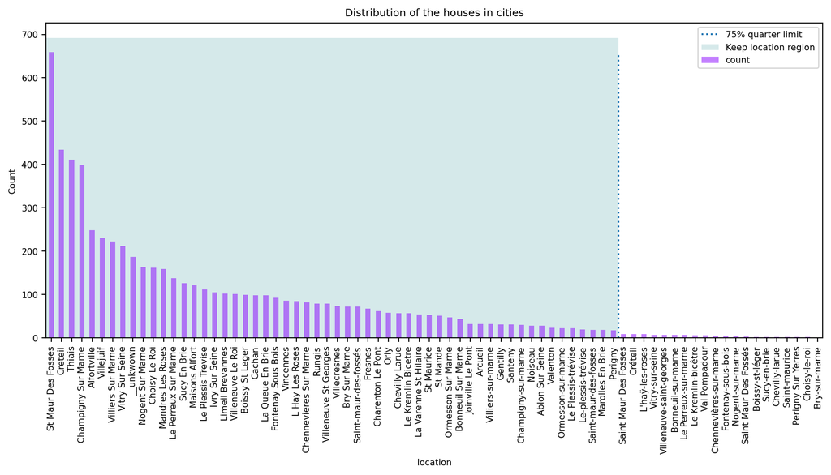

```python
third_quarter = sorted_locations["count"].quantile(1 - 3 / 4)
third_quarter_locations = sorted_locations[sorted_locations["count"] > third_quarter].location.values

# in_loc = sorted_locations[sorted_locations["count"] > third_quarter]
# not_in_loc = sorted_locations[sorted_locations["count"] <= third_quarter]

fig, ax = plt.subplots()

quarter_idx = len(third_quarter_locations) - 0.5
count_max = sorted_locations["count"].max() * 1.05
x, y = [-1, quarter_idx, quarter_idx, -1], [0, 0, count_max, count_max]
ax.fill(x, y, "#2f959933", label='Keep location region')
sorted_locations.plot(x='location', kind='bar', color="#8800ff", alpha=0.5, ax=ax)
ax.axvline(x=quarter_idx , ymin=0, ymax=0.9, linestyle=":", label='75% quarter limit')
ax.legend()
plt.title('Distribution of the houses in cities')
plt.xlabel('location')
plt.ylabel('Count')
pass
```

```python
print(f'Changement des villes dans les 25% les moins présentes ({len(df.loc[~df.location.isin(third_quarter_locations)])} villes) par "Autres"')
df.loc[~df.location.isin(third_quarter_locations), "location"] = "Autres"
```

```
Changement des villes dans les 25% les moins présentes (97 villes) par "Autres"
```

#### Finalisation de la préparation

Enfin maintenant qu'on a en mémoire le scaler dans l'objet **scaler** on peut d'un coup finaliser la préparation du dataframe.

```python
print(json.dumps(scaler.scales, indent=4))
```

```
{
    "price": {
        "log": {
            "maxi": 1999999.0
        },
        "t": "standardize",
        "pre_t": "pos_log",
        "t_kwargs": {
            "mean": 12.81437222793512,
            "std": 0.5125687200683336
        }
    },
    "area": {
        "log": {
            "maxi": 715.0
        },
        "t": "standardize",
        "pre_t": "pos_log",
        "t_kwargs": {
            "mean": 4.31656582308115,
            "std": 0.4823798305034632
        }
    },
    "n_bedroom": {
        "log": {
            "maxi": 19.705371805215147
        },
        "t": "standardize",
        "pre_t": "pos_log",
        "t_kwargs": {
            "mean": 1.1841381034121006,
            "std": 0.3591015005893609
        }
    },
    "n_room": {
        "log": {
            "maxi": 19.707140893762585
        },
        "t": "standardize",
        "pre_t": "pos_log",
        "t_kwargs": {
            "mean": 1.4975359418274108,
            "std": 0.3415581662435527
        }
    }
}
```

```python
df.describe()
```

|  | area | flag | is_appartement | is_maison | is_propriété | is_terrain | is_vente | is_viager | is_villa | n_bedroom | n_picture | n_room | price |
| --- | --- | --- | --- | --- | --- | --- | --- | --- | --- | --- | --- | --- | --- |
| count | 6336.000000 | 6336.000000 | 6336.000000 | 6336.000000 | 6336.000000 | 6336.0 | 6336.000000 | 6336.000000 | 6336.000000 | 6336.000000 | 6336.000000 | 6336.000000 | 6.336000e+03 |
| mean | 83.685290 | 0.484848 | 0.745896 | 0.225852 | 0.000947 | 0.0 | 0.995581 | 0.004419 | 0.007891 | 2.479752 | 6.456282 | 3.736616 | 4.225246e+05 |
| std | 48.388236 | 0.499810 | 0.435390 | 0.418175 | 0.030761 | 0.0 | 0.066335 | 0.066335 | 0.088489 | 1.252729 | 2.784892 | 1.662366 | 2.561449e+05 |
| min | 9.000000 | 0.000000 | 0.000000 | 0.000000 | 0.000000 | 0.0 | 0.000000 | 0.000000 | 0.000000 | -0.196696 | 1.000000 | 1.000000 | 2.417500e+04 |
| 25% | 56.000000 | 0.000000 | 0.000000 | 0.000000 | 0.000000 | 0.0 | 1.000000 | 0.000000 | 0.000000 | 2.000000 | 4.000000 | 3.000000 | 2.620000e+05 |
| 50% | 72.000000 | 0.000000 | 1.000000 | 0.000000 | 0.000000 | 0.0 | 1.000000 | 0.000000 | 0.000000 | 2.000000 | 6.000000 | 3.000000 | 3.590000e+05 |
| 75% | 96.000000 | 1.000000 | 1.000000 | 0.000000 | 0.000000 | 0.0 | 1.000000 | 0.000000 | 0.000000 | 3.000000 | 9.000000 | 5.000000 | 4.830000e+05 |
| max | 715.000000 | 1.000000 | 1.000000 | 1.000000 | 1.000000 | 0.0 | 1.000000 | 1.000000 | 1.000000 | 19.705372 | 10.000000 | 19.707141 | 1.999999e+06 |

```python
scaler.transform_all_df(df)
df.describe()
```

|  | area | flag | is_appartement | is_maison | is_propriété | is_terrain | is_vente | is_viager | is_villa | n_bedroom | n_picture | n_room | price |
| --- | --- | --- | --- | --- | --- | --- | --- | --- | --- | --- | --- | --- | --- |
| count | 6.336000e+03 | 6336.000000 | 6336.000000 | 6336.000000 | 6336.000000 | 6336.0 | 6336.000000 | 6336.000000 | 6336.000000 | 6.336000e+03 | 6336.000000 | 6.336000e+03 | 6.336000e+03 |
| mean | -4.665180e-16 | 0.484848 | 0.745896 | 0.225852 | 0.000947 | 0.0 | 0.995581 | 0.004419 | 0.007891 | -2.512020e-16 | 6.456282 | -7.177199e-16 | 3.157968e-15 |
| std | 1.000000e+00 | 0.499810 | 0.435390 | 0.418175 | 0.030761 | 0.0 | 0.066335 | 0.066335 | 0.088489 | 1.000000e+00 | 2.784892 | 1.000000e+00 | 1.000000e+00 |
| min | -4.175093e+00 | 0.000000 | 0.000000 | 0.000000 | 0.000000 | 0.0 | 0.000000 | 0.000000 | 0.000000 | -3.907421e+00 | 1.000000 | -2.355056e+00 | -5.309057e+00 |
| 25% | -5.670108e-01 | 0.000000 | 0.000000 | 0.000000 | 0.000000 | 0.0 | 1.000000 | 0.000000 | 0.000000 | -2.381661e-01 | 4.000000 | -3.256885e-01 | -6.599479e-01 |
| 50% | -5.411997e-02 | 0.000000 | 1.000000 | 0.000000 | 0.000000 | 0.0 | 1.000000 | 0.000000 | 0.000000 | -2.381661e-01 | 6.000000 | -3.256885e-01 | -4.544127e-02 |
| 75% | 5.351491e-01 | 1.000000 | 1.000000 | 0.000000 | 0.000000 | 0.0 | 1.000000 | 0.000000 | 0.000000 | 5.629502e-01 | 9.000000 | 8.614156e-01 | 5.333954e-01 |
| max | 4.679123e+00 | 1.000000 | 1.000000 | 1.000000 | 1.000000 | 0.0 | 1.000000 | 1.000000 | 1.000000 | 5.141318e+00 | 10.000000 | 4.488087e+00 | 3.305480e+00 |

## Export du notebook

```python
%%capture
!jupyter nbconvert TD6_Webscrapping.ipynb  --to HTML --template classic
```